# Quarto and Rmarkdown

An authoring framework for data science

Jürgen Wilbert

University of Münster

2026-01-29

## Goals

- You know what markdown is.
- You know what you can do with Quarto and Rmarkdown.
- You can create your own Quarto and Rmarkdown files.

# Markdown and Rmarkdown

## What is **markdown**?

- It is a very simple document *markup language*. That is, it is a way to format a text.
- Similar but much simpler than **html**, or **rtf**.
- E.g. putting an asterisk around the text will make it italic and two asterisks bold:  
  *example* becomes *example*  
  **another example** becomes **another example**
- **markdown** was developed in 2004 by John Gruber as an easy way to create texts on websites.
- Texts in **markdown** are rendered (translated) to other markup languages before they are turned to webpages or documents.
- The idea is: You type a text with basic format tags and later let the computer render it to a more complex format.
- Due to its simplicity, **markdown** can be converted to *html*, *latex*, *docx*, *rtf*, ect. files.
- Markdown is widely applied on various sites (e.g., *GitHub, Reddit, Diaspora, OpenStreetMap, sourceForge*).

## Markdown

A text like this:

```
# Chaper 1

> If something is true, no amount of wishful thinking will change it *-Richard Dawkins*

We will discuss the following ideas:

1. The meaning of **life**
2. The end of **suffering**
3. The **noble eightfold path**

| Sanskrit| Meaning                                                           |
|---------|-------------------------------------------------------------------|
| dukkha  | suffering is an innate characteristic of existence.               |
| samudaya| together with *dukkha* arises *taṇhā* (craving).                  |
| nirodha | *dukkha* can be ended or contained by letting go of this *taṇhā.* |
| magga   | The *noble eightfold path* leads to the confinement.              |

Tabel 1: [The four noble truths](https://en.wikipedia.org/wiki/Four_Noble_Truths)
```

## Three outputs:

- Word
- html
- pdf

[figure not shown]

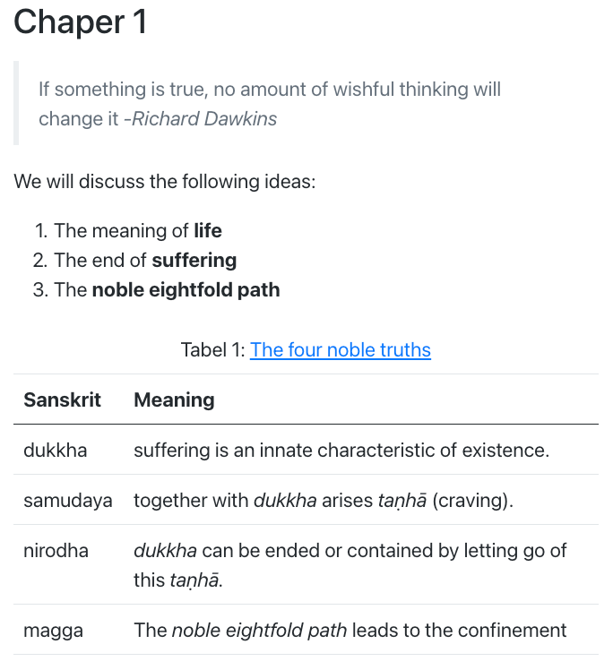

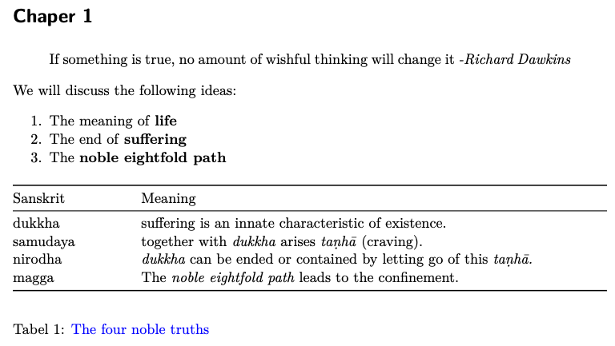

## Rmarkdown

- Rmarkdown is an extension to markdown.
- Specifically developed to combine data analyses (scripts and output) within a document.
- Think of it as an integration of a text-processing program and R code.
- You can write a text and implement tables, plots, figures etc. analysed with R.

## Why use Rmarkdown?

- Rmarkdown helps to make your research:
  - Transparent
  - Reproducible
  - Organized
  - Communicable

## Why use Rmarkdown?

- You can create individualized reports
  - E.g. results with a standard text for each participant in a study comprising their own data
  - E.g. individual analyses for each single school or classroom but with a common text.
  - You can even adapt text blocks depending on parameters and specific results (e.g. skip certain passages for special schools but not for primary schools)

## Task

# Basic markdown formating

## Basic markdown: header

- Normally written text appears as unformatted text.
- You can format text into a header with the `#` symbol:

```r
# A level one header
## A level two header
### A level three header
#### A level four header
```

## Basic markdown: Emphasise

- Italic text is put between `*` symbols (or `_`).
- Bold text between `**` symbols.
- Italic and bold text between `***` symbols.

`This is *italic* this is **bold**, and ***this is both!!!***.`

This is *italic* this is **bold**, and *this is both!!!*.

## Basic markdown: Lists

```r
An unordered list:

- Helmut
- Gerhard
- Angela

An ordered list:

1. Bush
2. Obama
3. Trump

Combined:

1. Sour
  - Lime
  - Envy
2. Sweet
  - Honey
  - love
```

# Rmarkdown

## Chunks

- `Chunks` are portions of R code within a markdown file.
- A chunk for R has the following structure:

```r
# Here comes the R code
```

## Chunk Options

- Chunk options specify the “behaviour” of a chunk.
- They start with `#|` and each option in set in a separate line.

e.g.:

```{r}

#| echo: false

#| include: false

# Here comes the R code  
```

- `echo: false` suppresses the inclusion of the original R code and only output is reported.
- `include: false` executes the R code but does not report anything
- `message: false` excludes additional messages given by a function.
- `warning: false` exclude warnings created by a function.

## Header

- Quarto documents start with a header that contains important document options. YAML you can set several document parameters.
- This header is put between leading and ending “—”.
- Information here are provided in a format called YAML (YAML is not a markup language)

```r
---

---
```

Some possible parameters:

- title: “My first document”
- author: “My Name”
- date: 27.11.2025
- abstract: This is an interesting paper

## Task

- Create a Quarto document with a “meaningful” header:

  ```r
  ---
  title: "My first document"
  author: "Your name"
  date: today
  abstract: This is an interesting paper
  format: html
  ---
  ```

- Add the example markdown code from above: Markdown
- Render the document

## Additional resources for Rmarkdown

- Quarto webpage  
  https://quarto.org/